# Kantr KO vs WT (Adult)

### PCA (genes)

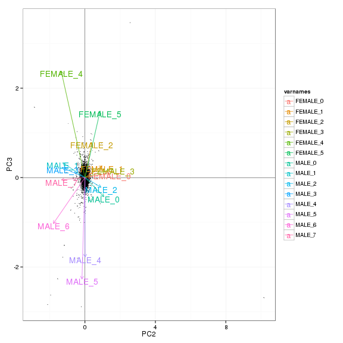

### MDS (genes)

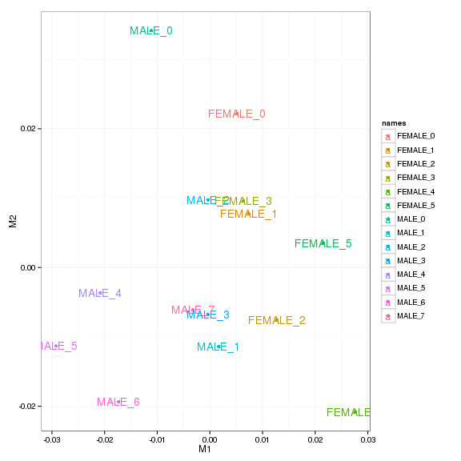

# KO assessment

## Endogenous lncRNA expression

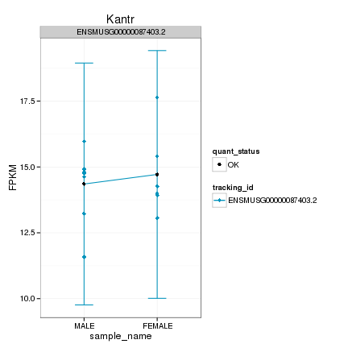

Endogenous expression of Kantr isoforms:

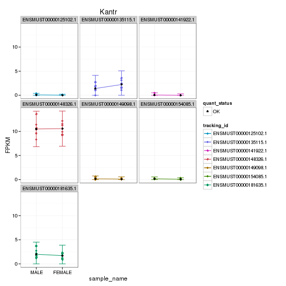

Barplot of gene expression:

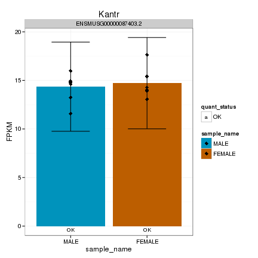

Barplot of isoform expression:

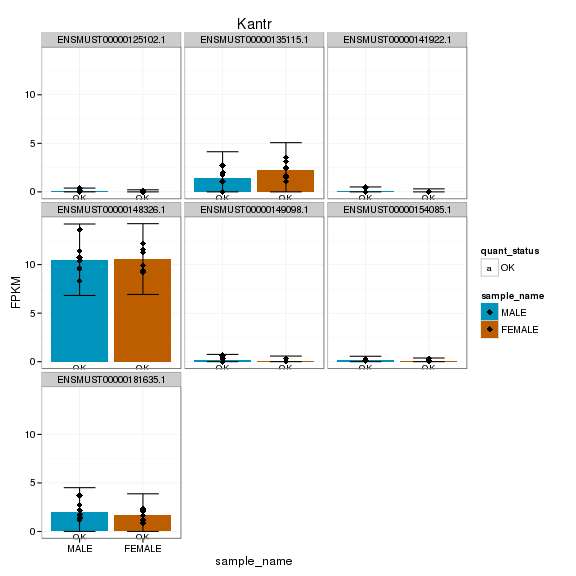

## LacZ expression

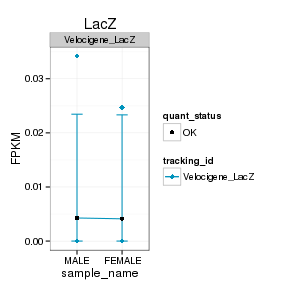

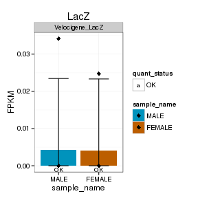

## Digital Genotyping (LacZ vs Endogenous lncRNA and Sex)

Eif2s3y is a y-expressed gene Expression plot (endogenous linc, lacZ, Y-expressed gene):

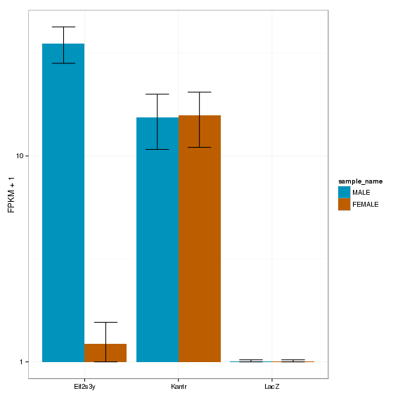

Expression heatmap:

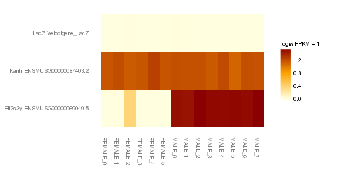

### Track visualization

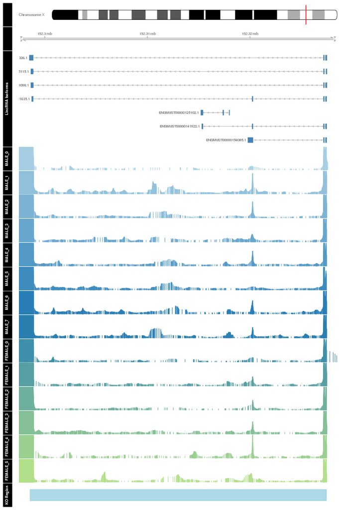

# Differential Analysis

## Differential Genes

There are 113 significantly differentially expressed genes. They are:

|  | geneAnnot$gene_short_name |
| --- | --- |
| 1 | Ddx3x |
| 2 | Col6a1 |
| 3 | Klf4 |
| 4 | Ranbp2 |
| 5 | Fosb |
| 6 | Nes |
| 7 | Epha2 |
| 8 | Rplp1 |
| 9 | Arl5b |
| 10 | Dusp6 |
| 11 | Timp3 |
| 12 | Pomc |
| 13 | Nfkbia |
| 14 | Serpina3n |
| 15 | Fos |
| 16 | Spry2 |
| 17 | Kcnv1 |
| 18 | Arc |
| 19 | Adamts1 |
| 20 | Nr4a1 |
| 21 | Cdkn1a |
| 22 | Wfdc1 |
| 23 | Glo1 |
| 24 | Zfp871 |
| 25 | Spry4 |
| 26 | Kdm5c |
| 27 | Rplp2 |
| 28 | Slc40a1 |
| 29 | Lcn2 |
| 30 | Nr4a2 |

[output cut: 83 more lines]

### Matrix of gene significant differences between conditions

(skip for Brainmap wt-v-ko comparisons)

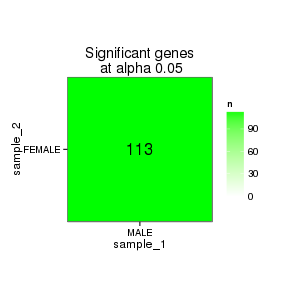

### Significant gene expression differences between conditions

Expression plot (genes):(turned off)

[figure not shown]

### Expression-level/significance relationship

Scatter plot of significant genes only:

[output not shown]

Volcano Plot

[output not shown]

Volcano plot with significant genes only:

[output not shown]

FoldChange Heatmap

[output not shown]

## Differential Splicing

### Differential Isoforms between conditions

Per isoform difference between conditions:

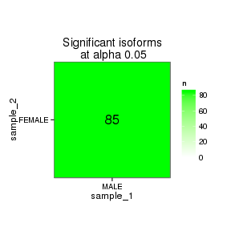

These isoforms are:

|  | isoAnnot$gene_short_name |
| --- | --- |
| 1 | Ddx3x |
| 2 | Col6a1 |
| 3 | Klf4 |
| 4 | Fosb |
| 5 | Hif3a |
| 6 | Nes |
| 7 | Prlr |
| 8 | Cyp2a5 |
| 9 | Epha2 |
| 10 | Zfp655 |
| 11 | Rplp1 |
| 12 | Arl5b |
| 13 | Dusp6 |
| 14 | Nfkbia |
| 15 | Serpina3n |
| 16 | Fos |
| 17 | Kcnv1 |
| 18 | Arc |
| 19 | Adamts1 |
| 20 | Nr4a1 |
| 21 | Cdkn1a |
| 22 | Wfdc1 |
| 23 | Glo1 |
| 24 | Spry4 |
| 25 | Kdm5c |
| 26 | Slc40a1 |
| 27 | Cyr61 |
| 28 | Slc2a1 |
| 29 | Tinagl1 |
| 30 | Fosl2 |

[output cut: 54 more lines]

Gene-level DE isoform heatmap

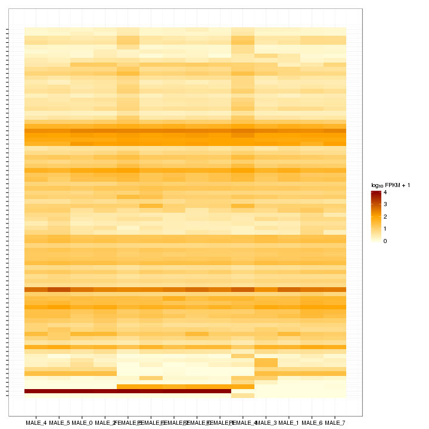

Isoform foldchange heatmap by isoform:

[output not shown]

### Differential Splicing between conditions

(eval false for first pass)

# Gene/Pathway Analysis

## GSEA

Biocarta enrichment:

```
## [1] "Not enough significant categories to print a heatmap!"
```

Biocarta zscore:

```
## [1] "Not enough significant categories to print a heatmap!"
```

Reactome enrichment:

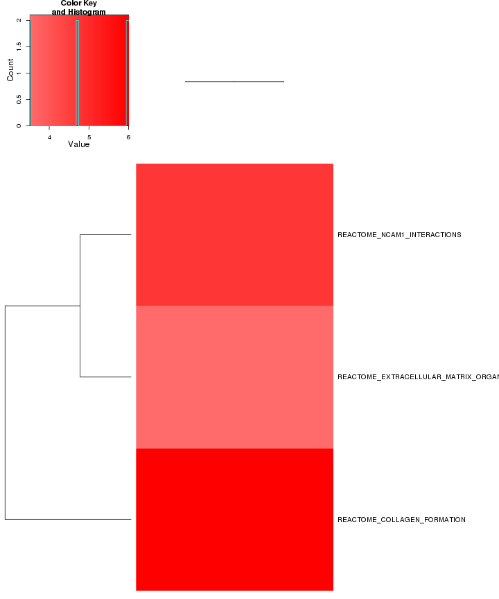

Reactome zscore:

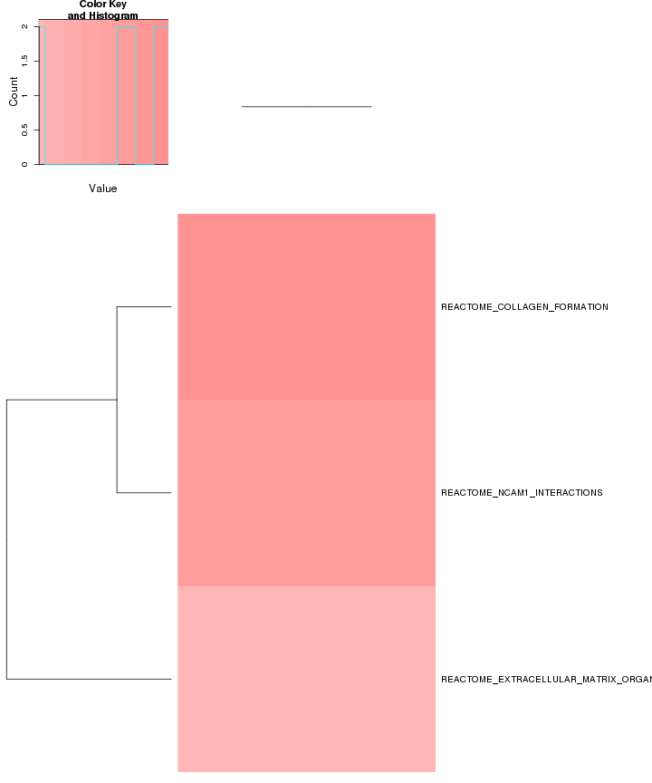

Kegg enrichment:

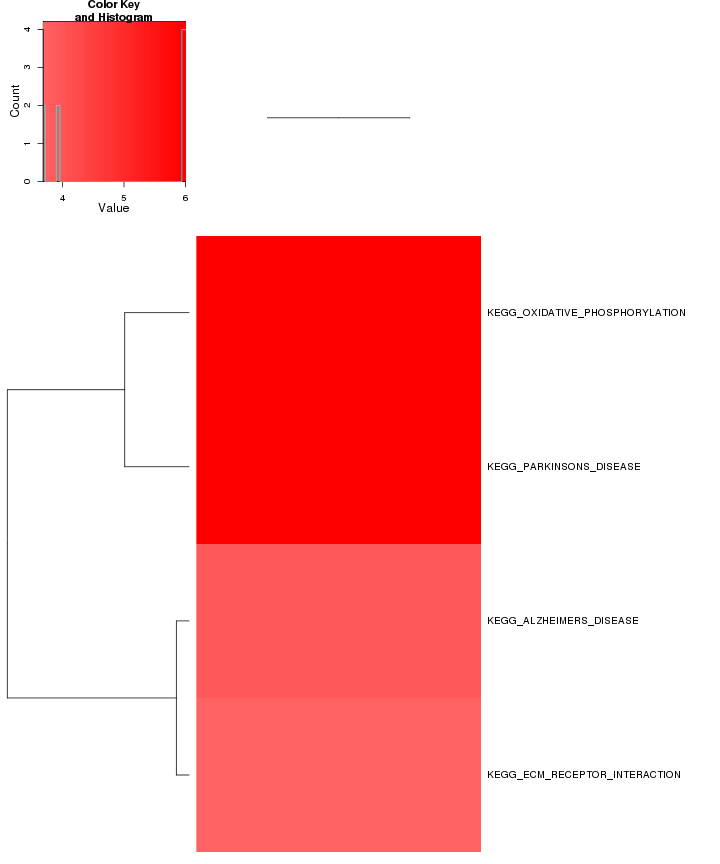

Kegg zscore:

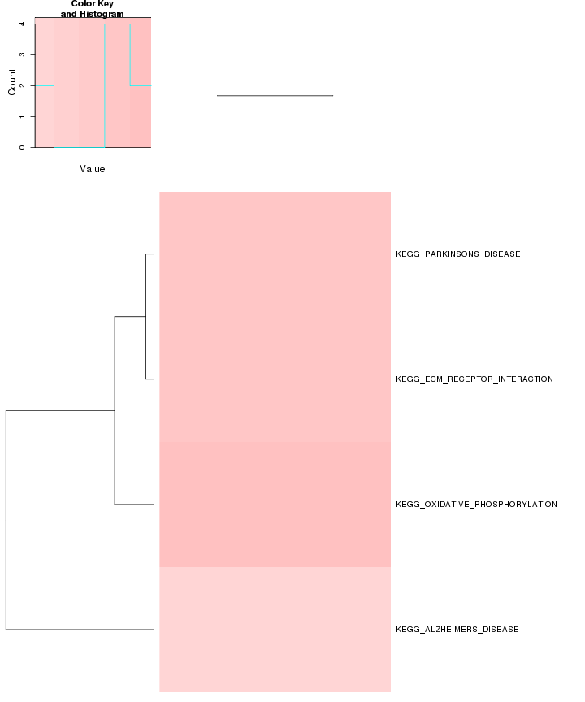

## GO enrichment

Cluster profiler used to call enichments of significantly differentially regulated genes that map to Entrez IDs.

[output not shown]

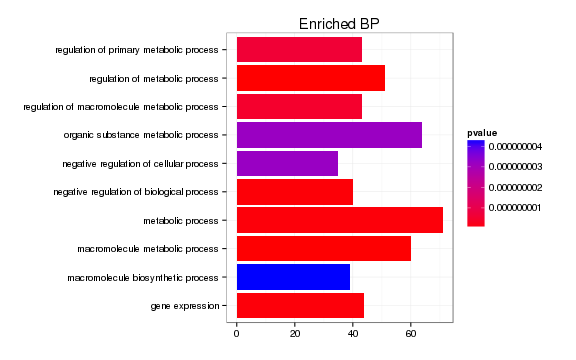

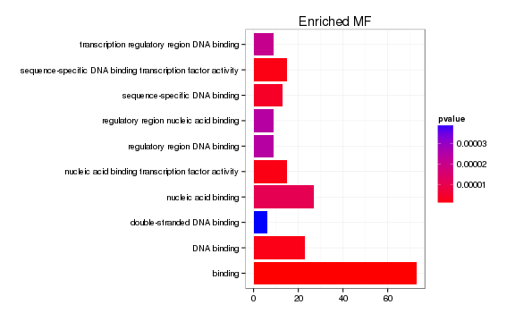

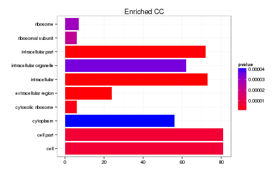

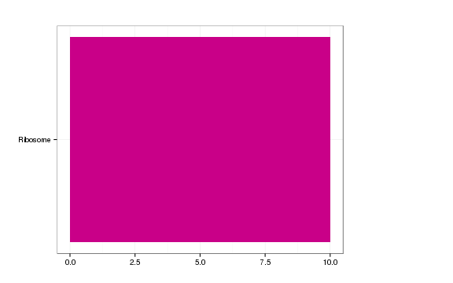

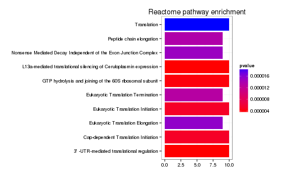

# Cis vs Trans (locally)

The pvalue for 1 genes significantly regulated in a region this size is: 1

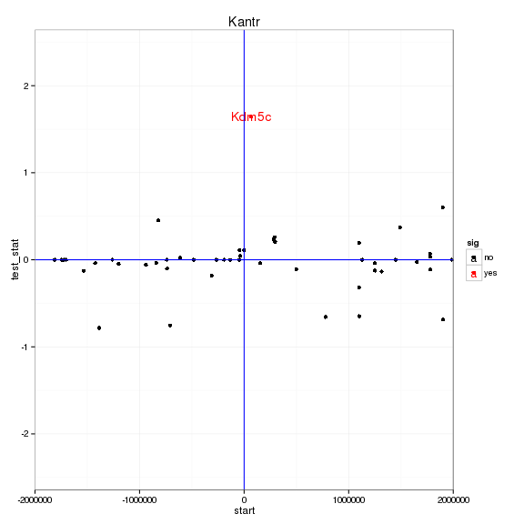

# Notes

## Samples used are:

|  | 10 |
| --- | --- |
| 1 | JR728 |
| 2 | JR803 |
| 3 | JR735 |
| 4 | JR781 |
| 5 | JR796 |
| 6 | JR797 |
| 7 | JR800 |
| 8 | JR778 |
| 9 | JR729 |
| 10 | JR740 |
| 11 | JR827 |
| 12 | JR734 |
| 13 | JR802 |
| 14 | JR785 |

## Replicates

|  | file | sample_name | replicate | rep_name | total_mass | norm_mass | internal_scale | external_scale |
| --- | --- | --- | --- | --- | --- | --- | --- | --- |
| 1 | /n/rinn_data1/seq/lgoff/Projects/BrainMap/data/quants/JR728/abundances.cxb | MALE | 0 | MALE_0 | 20329200.00 | 34174100.00 | 0.59 | 1.00 |
| 2 | /n/rinn_data1/seq/lgoff/Projects/BrainMap/data/quants/JR803/abundances.cxb | MALE | 1 | MALE_1 | 52130400.00 | 34174100.00 | 1.53 | 1.00 |
| 3 | /n/rinn_data1/seq/lgoff/Projects/BrainMap/data/quants/JR735/abundances.cxb | MALE | 2 | MALE_2 | 34994400.00 | 34174100.00 | 1.03 | 1.00 |
| 4 | /n/rinn_data1/seq/lgoff/Projects/BrainMap/data/quants/JR781/abundances.cxb | MALE | 3 | MALE_3 | 41538900.00 | 34174100.00 | 1.22 | 1.00 |
| 5 | /n/rinn_data1/seq/lgoff/Projects/BrainMap/data/quants/JR796/abundances.cxb | MALE | 4 | MALE_4 | 34089000.00 | 34174100.00 | 0.99 | 1.00 |
| 6 | /n/rinn_data1/seq/lgoff/Projects/BrainMap/data/quants/JR797/abundances.cxb | MALE | 5 | MALE_5 | 28103300.00 | 34174100.00 | 0.81 | 1.00 |
| 7 | /n/rinn_data1/seq/lgoff/Projects/BrainMap/data/quants/JR800/abundances.cxb | MALE | 6 | MALE_6 | 37012200.00 | 34174100.00 | 1.08 | 1.00 |
| 8 | /n/rinn_data1/seq/lgoff/Projects/BrainMap/data/quants/JR778/abundances.cxb | MALE | 7 | MALE_7 | 39541900.00 | 34174100.00 | 1.17 | 1.00 |
| 9 | /n/rinn_data1/seq/lgoff/Projects/BrainMap/data/quants/JR729/abundances.cxb | FEMALE | 0 | FEMALE_0 | 26334400.00 | 34174100.00 | 0.77 | 1.00 |
| 10 | /n/rinn_data1/seq/lgoff/Projects/BrainMap/data/quants/JR740/abundances.cxb | FEMALE | 1 | FEMALE_1 | 35808200.00 | 34174100.00 | 1.05 | 1.00 |
| 11 | /n/rinn_data1/seq/lgoff/Projects/BrainMap/data/quants/JR827/abundances.cxb | FEMALE | 2 | FEMALE_2 | 27786600.00 | 34174100.00 | 0.82 | 1.00 |
| 12 | /n/rinn_data1/seq/lgoff/Projects/BrainMap/data/quants/JR734/abundances.cxb | FEMALE | 3 | FEMALE_3 | 34480600.00 | 34174100.00 | 1.02 | 1.00 |
| 13 | /n/rinn_data1/seq/lgoff/Projects/BrainMap/data/quants/JR802/abundances.cxb | FEMALE | 4 | FEMALE_4 | 45467400.00 | 34174100.00 | 1.32 | 1.00 |
| 14 | /n/rinn_data1/seq/lgoff/Projects/BrainMap/data/quants/JR785/abundances.cxb | FEMALE | 5 | FEMALE_5 | 34173600.00 | 34174100.00 | 0.99 | 1.00 |

## Run Info

[output not shown]